# Sea level pressure in the Gulf of California

Sea level is scored as a pressure for the nine marine OHI regions of the Gulf of California. The measurement is the gridded satellite sea-level anomaly.

The anomaly is a height in metres, already relative to the 1993–2012 mean. Each coastal cell is fit with an ordinary linear regression:

anomaly = intercept + (rate × year) + (El Niño term × Oceanic Niño Index)

The Oceanic Niño Index is positive in El Niño years and negative in La Niña years, so one term takes out both. The pressure uses the slope on year from 2000 through 2025. A second slope, fit to every year from 1993 through 2025, is drawn on the same figure. The rate is stored in millimetres per year. The pressure is the 2000–2025 rate divided by 10. A rate of 0 is pressure 0. A rate of 10 mm per year is pressure 1. Faster than that stays at 1, and a falling sea surface stays at 0.

Each region is saved once, for 2025. The cells that enter the regional mean are the ocean cells that share a side with land. Empty land cells stay empty.

```r
library(terra)
library(sf)
library(tidyverse)
library(exactextractr)
library(knitr)
```

```r
knitr::opts_chunk$set(fig.width = 8, fig.height = 6.5, message = FALSE, warning = FALSE)

data_dir <- "/home/shares/ohi/fisheries_explore/data/SLR_CMEM"
int_dir <- "/home/shares/ohi/fisheries_explore/int/prs_slr"
out_dir <- "/home/frazier/ohi_goc_prep/_pressures/prs_slr/outputs"
rgn_path <- "/home/shares/ohi/OHI_GOC/spatial/OHI_regions/goc_ohi_rgns.shp"

dir.create(file.path(int_dir, "annual_sla"), showWarnings = FALSE, recursive = TRUE)
dir.create(out_dir, showWarnings = FALSE, recursive = TRUE)

# Drop rasters written by the earlier year-by-year score.
unlink(file.path(int_dir, c("raw_rate", "rescaled", "coastal")), recursive = TRUE)
unlink(file.path(int_dir, "sla_baseline_1993_2002.tif"))

years <- 1993:2025
trend_start <- 2000
score_year <- 2025
```

## 1. Monthly sea level anomaly

The fields are monthly means from the DUACS multi-satellite gridded sea level anomaly, product `SEALEVEL_GLO_PHY_L4_MY_008_047`, dataset `cmems_obs-sl_glo_phy-ssh_my_allsat-l4-duacs-0.125deg_P1M-m`, version `202411`. The variable is `sla`, in metres. Copernicus Marine Service distributes the global files. The Gulf subset was saved with `copernicusmarine.subset()` as `goc_duacs_sla_monthly_1993_2025.nc`.

The box is longitude −115.5 to −104.5 and latitude 20.0 to 32.25, which covers the marine OHI regions with a small margin. January 1993 through December 2025 are included. 2026 is only a partial year, so it is left out. The grid is 0.125°, about 14 km north–south and 12–13 km east–west in the Gulf.

```r
monthly <- rast(file.path(data_dir, "goc_duacs_sla_monthly_1993_2025.nc"))
names(monthly) <- format(time(monthly), "%Y-%m")
monthly <- ifel(is.nan(monthly), NA, monthly)

range(time(monthly))
```

```
## [1] "1993-01-01" "2025-12-01"
```

```r
nlyr(monthly)
```

```
## [1] 396
```

```r
res(monthly)
```

```
## [1] 0.125 0.125
```

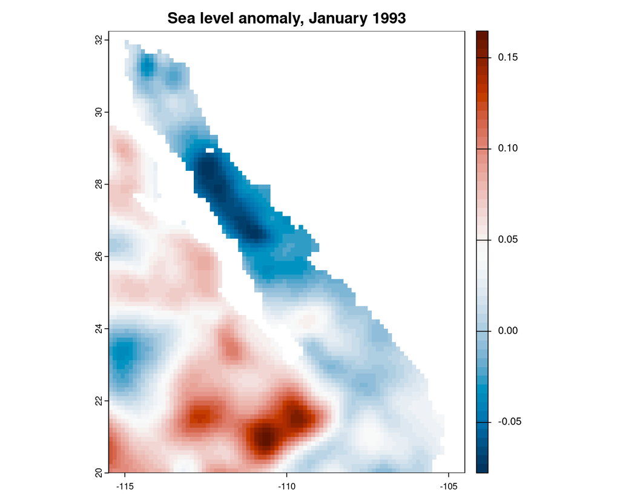

```r
plot(
  monthly[["1993-01"]],
  main = "Sea level anomaly, January 1993",
  col = hcl.colors(50, "RdBu", rev = TRUE)
)
```

## 2. Annual means

Each year becomes the mean of its twelve months. The seasonal cycle averages out, and these 33 heights are what the line is fit to. They are written to `int/prs_slr/annual_sla` as `sla_<year>.tif`.

```r
year_index <- as.integer(format(time(monthly), "%Y"))
annual <- tapp(monthly, year_index, fun = mean, na.rm = TRUE)
annual <- ifel(is.nan(annual), NA, annual)
names(annual) <- as.character(years)

stopifnot(as.integer(names(annual)) == years)
month_counts <- tibble(year = year_index) %>% count(year)
stopifnot(all(month_counts$n == 12), all(month_counts$year == years))

for (yr in names(annual)) {
  writeRaster(
    annual[[yr]],
    file.path(int_dir, "annual_sla", sprintf("sla_%s.tif", yr)),
    overwrite = TRUE
  )
}

summary(values(annual[["2025"]]))
```

```
##       2025
##  Min.   :0.031
##  1st Qu.:0.074
##  Median :0.082
##  Mean   :0.082
##  3rd Qu.:0.090
##  Max.   :0.142
##  NA's   :4233
```

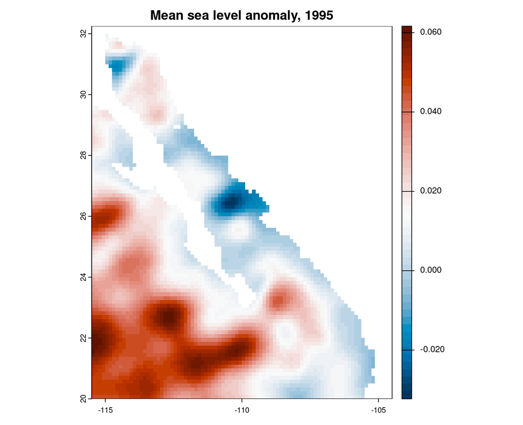

```r
plot(annual[["1995"]], main = "Mean sea level anomaly, 1995", col = hcl.colors(50, "RdBu", rev = TRUE))
```

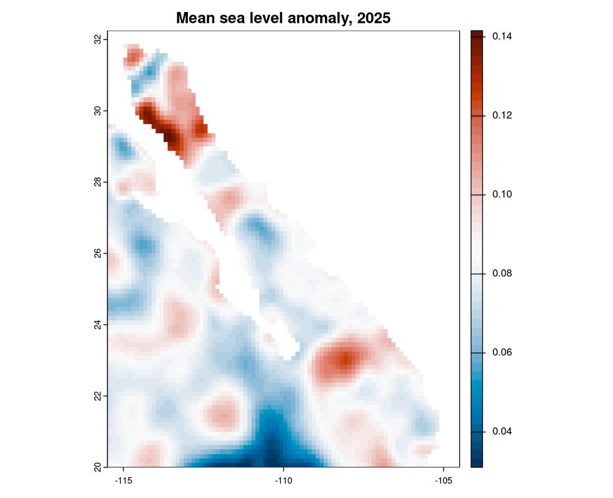

```r
plot(annual[["2025"]], main = "Mean sea level anomaly, 2025", col = hcl.colors(50, "RdBu", rev = TRUE))
```

## 3. Cells against the land

An ocean cell is kept when one of the four cells that share a side with it is land. Land is an empty cell. Every ocean cell in this grid has a value in all 33 years. Corner contact is left out, so the set is a single line of cells along the shore, including islands.

The line is then limited to cells the marine OHI regions touch. That drops ocean cells on the Pacific side of the peninsula that happen to fall inside the download box. Nothing is interpolated onto land.

```r
n_obs <- app(annual, fun = function(v) sum(!is.na(v)))
ocean <- ifel(n_obs == nlyr(annual), 1, 0)
land <- ifel(ocean == 1, 0, 1)
side <- matrix(c(
  0, 1, 0,
  1, 0, 1,
  0, 1, 0
), nrow = 3)
n_land <- focal(land, w = side, fun = "sum", na.rm = TRUE)
coast <- ifel(ocean == 1 & n_land >= 1, 1, NA)

marine <- st_read(rgn_path, quiet = TRUE) %>%
  filter(location == "marine") %>%
  st_transform(4326) %>%
  arrange(rgn_id) %>%
  mutate(label = paste(rgn_id, estado, ecorgn, sep = "\n"))

marine_cells <- rasterize(vect(marine), coast, touches = TRUE)
coast <- mask(coast, marine_cells)
names(coast) <- "coastal_cell"

writeRaster(
  coast,
  file.path(int_dir, "coastal_cells.tif"),
  overwrite = TRUE
)

global(coast, "sum", na.rm = TRUE)
```

```
##              sum
## coastal_cell 208
```

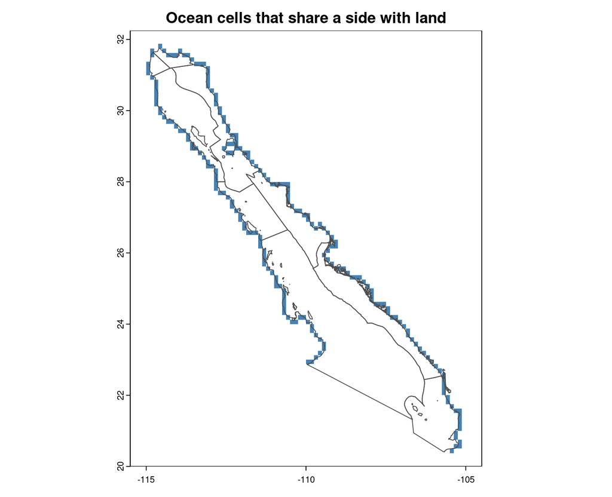

```r
plot(coast, col = "steelblue", legend = FALSE, main = "Ocean cells that share a side with land")
lines(vect(marine), col = "grey30")
```

## 4. Oceanic Niño Index

The index is the NOAA Climate Prediction Center Oceanic Niño Index, from `oni.ascii.txt`. Each row is a three-month season. The season labeled DJF of a year includes December of the year before. The covariate used here is the mean of the twelve seasons labeled with that calendar year. Positive values are El Niño. Negative values are La Niña. The raw table and the annual means are saved under `int/prs_slr`.

```r
oni_url <- "https://www.cpc.ncep.noaa.gov/data/indices/oni.ascii.txt"
oni_raw_path <- file.path(int_dir, "oni_noaa_cpc.txt")
download.file(oni_url, oni_raw_path, quiet = TRUE)

oni <- read_table(oni_raw_path, show_col_types = FALSE) %>%
  rename(year = YR) %>%
  filter(year %in% years) %>%
  group_by(year) %>%
  summarise(oni = mean(ANOM), n_seasons = n(), .groups = "drop")

stopifnot(oni$year == years, oni$n_seasons == 12)

oni_path <- file.path(int_dir, "oni_annual_1993_2025.csv")
write_csv(oni %>% select(year, oni), oni_path)
oni
```

```
## # A tibble: 33 × 3
##     year     oni n_seasons
##    <dbl>   <dbl>     <int>
##  1  1993  0.357         12
##  2  1994  0.366         12
##  3  1995 -0.216         12
##  4  1996 -0.406         12
##  5  1997  1.14          12
##  6  1998  0.0417        12
##  7  1999 -1.08          12
##  8  2000 -0.766         12
##  9  2001 -0.294         12
## 10  2002  0.514         12
## # ℹ 23 more rows
```

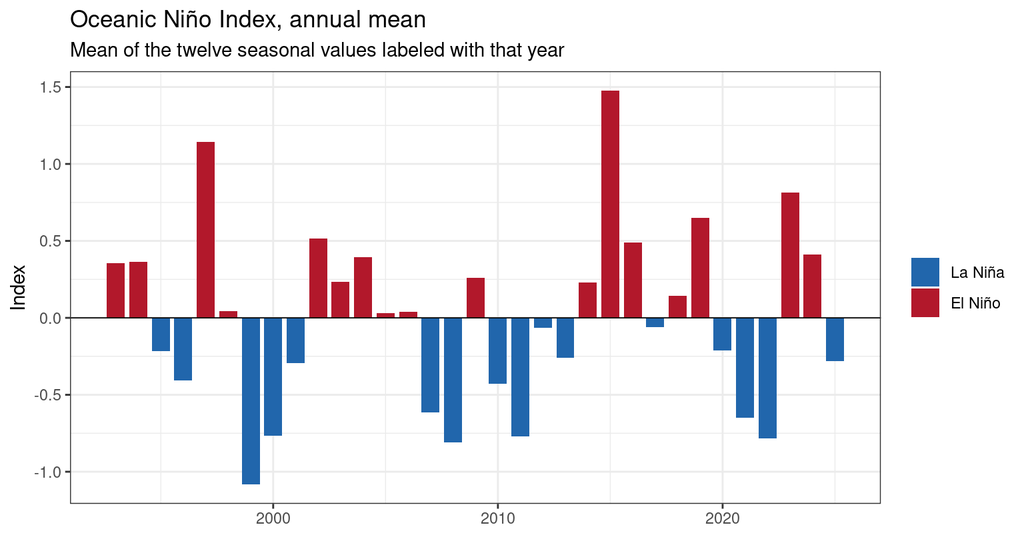

```r
ggplot(oni, aes(year, oni, fill = oni >= 0)) +
  geom_col(width = 0.8) +
  geom_hline(yintercept = 0, linewidth = 0.3) +
  scale_fill_manual(
    values = c("TRUE" = "#b2182b", "FALSE" = "#2166ac"),
    labels = c("TRUE" = "El Niño", "FALSE" = "La Niña"),
    name = NULL
  ) +
  labs(
    title = "Oceanic Niño Index, annual mean",
    subtitle = "Mean of the twelve seasonal values labeled with that year",
    x = NULL,
    y = "Index"
  ) +
  theme_bw()
```

## 5. Rate, with El Niño and La Niña removed

Each coastal cell gets two ordinary linear regressions. The anomaly is in metres. `year` runs from 1993 through 2025. `oni` is the Oceanic Niño Index for that year.

anomaly = intercept + (rate × year) + (El Niño term × oni)

The coefficient on `year` is the rise in metres per year. Multiplying by 1000 stores it as millimetres per year. The pressure uses the regression fit only to 2000–2025. Dividing that rate by 10 and holding the result between 0 and 1 gives the pressure. The regression fit to all 33 years is kept for the comparison line.

A third regression, 2000–2025 with the year alone, shows the rate before the Niño index is added. The saved pressure uses the 2000–2025 regression that includes the index.

A steady 3 mm per year scores 0.3.

```r
cell_sla <- values(mask(annual, coast))
complete <- which(rowSums(!is.na(cell_sla)) == ncol(cell_sla))

fit_table <- map(complete, function(cell) {
  series <- tibble(
    year = years,
    anomaly_m = cell_sla[cell, ],
    oni = oni$oni
  )
  full <- lm(anomaly_m ~ year + oni, data = series)
  recent <- series %>% filter(year >= trend_start)
  from_2000 <- lm(anomaly_m ~ year + oni, data = recent)
  year_only <- lm(anomaly_m ~ year, data = recent)
  tibble(
    cell = cell,
    rate_full_mm_yr = coef(full)[["year"]] * 1000,
    rate_mm_yr = coef(from_2000)[["year"]] * 1000,
    rate_year_only_mm_yr = coef(year_only)[["year"]] * 1000,
    enso_m = coef(from_2000)[["oni"]]
  )
}) %>%
  list_rbind()

empty <- rast(annual[[1]])
values(empty) <- NA

rate <- empty
rate[fit_table$cell] <- fit_table$rate_mm_yr
names(rate) <- "mm_per_year_2000_2025"

rate_full <- empty
rate_full[fit_table$cell] <- fit_table$rate_full_mm_yr
names(rate_full) <- "mm_per_year_1993_2025"

rate_year_only <- empty
rate_year_only[fit_table$cell] <- fit_table$rate_year_only_mm_yr
names(rate_year_only) <- "mm_per_year_2000_2025_year_only"

enso <- empty
enso[fit_table$cell] <- fit_table$enso_m
names(enso) <- "metres_per_oni"

unlink(file.path(int_dir, "slr_rate_mm_yr.tif"))

pressure <- clamp(rate / 10, lower = 0, upper = 1, values = TRUE)
names(pressure) <- "pressure"

writeRaster(rate, file.path(int_dir, "slr_rate_2000_2025_mm_yr.tif"), overwrite = TRUE)
writeRaster(rate_full, file.path(int_dir, "slr_rate_1993_2025_mm_yr.tif"), overwrite = TRUE)
writeRaster(pressure, file.path(int_dir, "slr_pressure.tif"), overwrite = TRUE)
writeRaster(enso, file.path(int_dir, "slr_enso_m_per_oni.tif"), overwrite = TRUE)

summary(values(rate))
```

```
##  mm_per_year_2000_2025
##  Min.   :0.673
##  1st Qu.:2.979
##  Median :3.134
##  Mean   :3.149
##  3rd Qu.:3.337
##  Max.   :5.567
##  NA's   :8416
```

```r
summary(values(pressure))
```

```
##     pressure
##  Min.   :0.067
##  1st Qu.:0.298
##  Median :0.313
##  Mean   :0.315
##  3rd Qu.:0.334
##  Max.   :0.557
##  NA's   :8416
```

```r
summary(values(enso) * 100)
```

```
##  metres_per_oni
##  Min.   :0.397
##  1st Qu.:2.977
##  Median :3.564
##  Mean   :3.406
##  3rd Qu.:3.957
##  Max.   :4.790
##  NA's   :8416
```

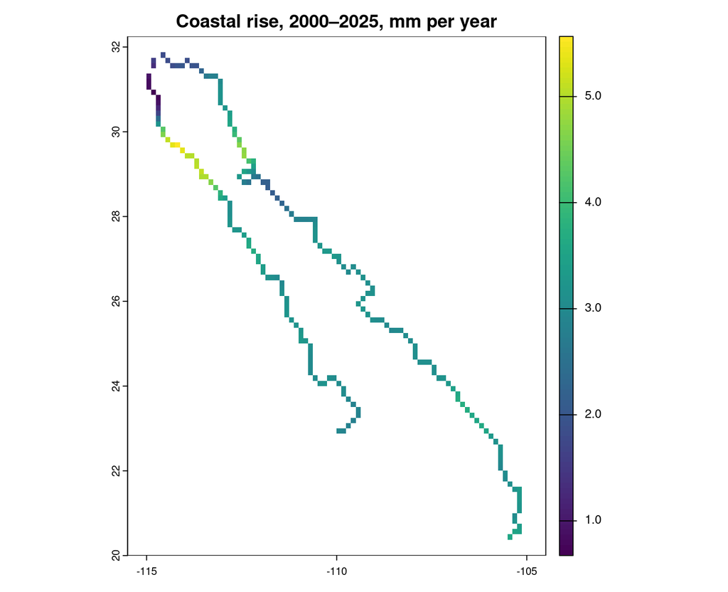

```r
pressure_colors <- colorRampPalette(c("#2166ac", "#67a9cf", "#f7f7f7", "#ef8a62", "#b2182b"))(100)
plot(rate, main = "Coastal rise, 2000–2025, mm per year")
```

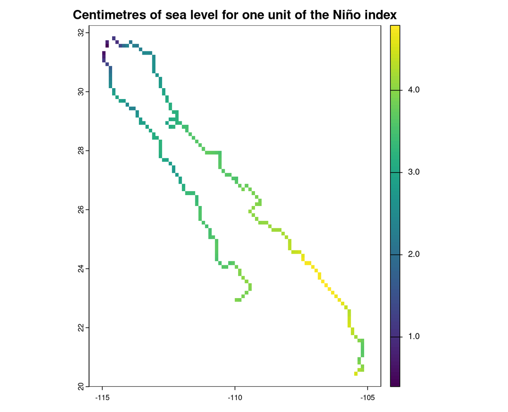

```r
plot(enso * 100, main = "Centimetres of sea level for one unit of the Niño index")
```

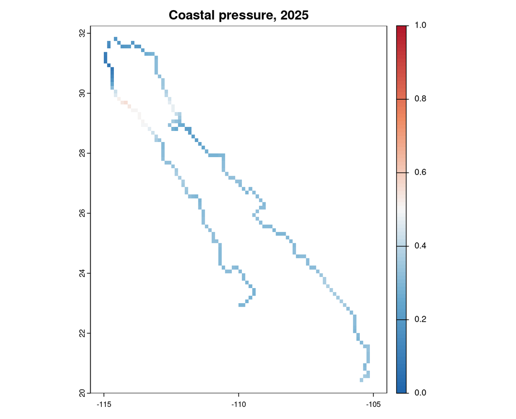

```r
plot(
  pressure,
  main = "Coastal pressure, 2025",
  range = c(0, 1),
  col = pressure_colors
)
```

The middle map is the El Niño term from the 2000–2025 fit. One unit of the index is a moderate event. A strong El Niño is closer to 1.5 or 2, and a La Niña is the same size with the opposite sign. The southern Gulf moves more with the index than the upper Gulf does.

On the pressure map, blue is 0 and red is 1. These coastal pressures sit in the lower part of that scale.

## 6. Mean pressure in each marine region

Each coastal cell is weighted by how much of it sits inside the region. The saved pressure is the mean of the cell pressures, after each cell has been held between 0 and 1. The year on every row is 2025.

```r
regional <- tibble(
  rgn_id = marine$rgn_id,
  estado = marine$estado,
  ecorgn = marine$ecorgn,
  label = marine$label,
  year = score_year,
  n_cells = exact_extract(pressure, marine, "count"),
  rate_mm_yr = exact_extract(rate, marine, "mean"),
  rate_full_mm_yr = exact_extract(rate_full, marine, "mean"),
  rate_year_only_mm_yr = exact_extract(rate_year_only, marine, "mean"),
  enso_cm = exact_extract(enso, marine, "mean") * 100,
  pressure = exact_extract(pressure, marine, "mean")
) %>%
  arrange(rgn_id)
```

[output not shown]

```r
annual_cm <- mask(annual, coast) * 100
names(annual_cm) <- as.character(years)
anom_mean <- exact_extract(annual_cm, marine, "mean")
```

[output not shown]

```r
anomaly_scores <- anom_mean %>%
  as_tibble() %>%
  mutate(rgn_id = marine$rgn_id, label = marine$label) %>%
  pivot_longer(
    cols = starts_with("mean."),
    names_to = "year",
    names_prefix = "mean.",
    names_transform = list(year = as.integer),
    values_to = "anomaly_cm"
  ) %>%
  left_join(regional %>% select(rgn_id, rate_mm_yr, rate_full_mm_yr, enso_cm), by = "rgn_id") %>%
  left_join(oni %>% transmute(year, oni_c = oni - mean(oni)), by = "year") %>%
  mutate(
    adjusted_cm = anomaly_cm - enso_cm * oni_c,
    trend_full_cm = mean(anomaly_cm) + (rate_full_mm_yr / 10) * (year - mean(years)),
    trend_2000_cm = if_else(
      year >= trend_start,
      mean(anomaly_cm[year >= trend_start]) +
        (rate_mm_yr / 10) * (year - mean(year[year >= trend_start])),
      NA_real_
    ),
    .by = rgn_id
  )

pressure_csv <- regional %>%
  select(rgn_id, year, pressure) %>%
  arrange(rgn_id)

csv_path <- file.path(out_dir, "slr_pressure.csv")
write_csv(pressure_csv, csv_path)

kable(
  regional %>%
    select(
      rgn_id, estado, ecorgn, n_cells,
      rate_mm_yr, rate_full_mm_yr, rate_year_only_mm_yr, enso_cm, pressure
    ),
  digits = 3,
  col.names = c(
    "Region", "State", "Ecoregion", "Cells",
    "Rate, 2000–2025", "Rate, 1993–2025", "Rate, 2000–2025, year only",
    "cm per Niño unit", "Pressure"
  ),
  caption = "Coastal rate and pressure for 2025. The pressure uses the 2000–2025 rate, in mm per year, from the fit that includes the Niño index."
)
```

Coastal rate and pressure for 2025. The pressure uses the 2000–2025 rate, in mm per year, from the fit that includes the Niño index.

| Region | State | Ecoregion | Cells | Rate, 2000–2025 | Rate, 1993–2025 | Rate, 2000–2025, year only | cm per Niño unit | Pressure |
| --- | --- | --- | --- | --- | --- | --- | --- | --- |
| Region_1 | Baja_California | Upper_Gulf | 0.981 | 1.187 | 1.058 | 1.247 | 0.568 | 0.119 |
| Region_2 | Baja_California | Midriff_Region | 9.784 | 3.626 | 2.995 | 3.914 | 2.740 | 0.363 |
| Region_3 | Baja_California_Sur | Central_Gulf | 4.198 | 3.263 | 2.691 | 3.588 | 3.092 | 0.326 |
| Region_4 | Baja_California_Sur | Southern_Gulf | 11.972 | 3.066 | 2.372 | 3.455 | 3.696 | 0.307 |
| Region_5 | Sonora | Upper_Gulf | 1.794 | 1.890 | 1.455 | 2.077 | 1.774 | 0.189 |
| Region_6 | Sonora | Midriff_Region | 10.555 | 3.374 | 2.554 | 3.696 | 3.053 | 0.337 |
| Region_7 | Sonora | Central_Gulf | 8.354 | 3.037 | 2.263 | 3.424 | 3.676 | 0.304 |
| Region_8 | Sinaloa | Southern_Gulf | 8.691 | 3.269 | 2.329 | 3.735 | 4.422 | 0.327 |
| Region_9 | Nayarit | Southern_Gulf | 6.080 | 3.147 | 2.460 | 3.594 | 4.241 | 0.315 |

The figure below draws both slopes. The blue line is the fit to every year from 1993 through 2025. The red line is the fit to 2000–2025, which is the slope used for the pressure, and it is drawn only from 2000 onward. The points have the Niño term from that 2000–2025 fit removed.

The year-only rate leaves El Niño and La Niña in the 2000–2025 slope. Including the index lowers that rate by 0.06 to 0.47 mm per year. The upper Gulf rests on about one cell in Baja California and about two in Sonora.

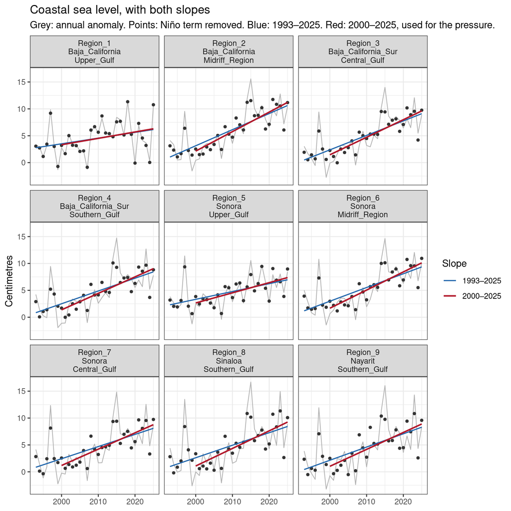

```r
ggplot(anomaly_scores, aes(year)) +
  geom_line(aes(y = anomaly_cm), color = "grey70", linewidth = 0.4) +
  geom_point(aes(y = adjusted_cm), size = 1.1, color = "grey20") +
  geom_line(aes(y = trend_full_cm, color = "1993–2025"), linewidth = 0.6) +
  geom_line(aes(y = trend_2000_cm, color = "2000–2025"), linewidth = 0.8) +
  scale_color_manual(
    values = c("1993–2025" = "#2166ac", "2000–2025" = "#b2182b"),
    name = "Slope"
  ) +
  facet_wrap(vars(label), ncol = 3) +
  labs(
    title = "Coastal sea level, with both slopes",
    subtitle = "Grey: annual anomaly. Points: Niño term removed. Blue: 1993–2025. Red: 2000–2025, used for the pressure.",
    x = NULL,
    y = "Centimetres"
  ) +
  theme_bw()
```

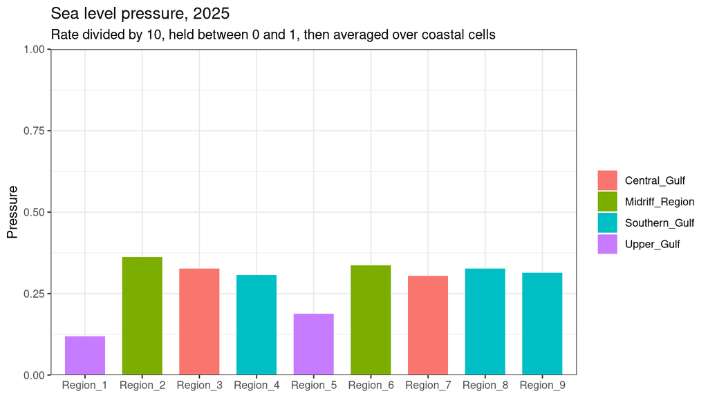

```r
ggplot(regional, aes(reorder(rgn_id, rgn_id), pressure, fill = ecorgn)) +
  geom_col(width = 0.7) +
  scale_y_continuous(limits = c(0, 1), expand = c(0, 0)) +
  labs(
    title = "Sea level pressure, 2025",
    subtitle = "Rate divided by 10, held between 0 and 1, then averaged over coastal cells",
    x = NULL,
    y = "Pressure",
    fill = NULL
  ) +
  theme_bw()
```

The table is /home/frazier/ohi_goc_prep/_pressures/prs_slr/outputs/slr_pressure.csv.

## 7. Comparison with other sea-level rates

Three other rates were examined while this pressure was being chosen.

The CryoSat-2 study of the Gulf entrance compared coastal altimetry with tide gauges at Cabo San Lucas and Mazatlán for 2011–2020 ([Valle-Rodríguez, Gómez-Enri, and Trasviña-Castro, Advances in Space Research, 2023](https://doi.org/10.1016/j.asr.2023.08.048)). Both shores gave a trend of about 3.1 mm per year. San Blas, farther south, agreed less well with its gauge. That study did not cover the upper Gulf.

An earlier pass used the GLORYS ocean model for the same Gulf regions. Those rates are the 2025 coastal endpoint, the rise from the 1993–2002 mean divided by the years since 1997.5. They are not a regression, and they are not the pressure saved here. At the southern mouth the model was about 1.1 to 1.4 mm per year, while the upper Gulf was about 3.2. Global altimetry over the satellite era is about 3.3 mm per year, and that model is known to run slower than the satellites, near 2.7 mm per year.

The habitat threshold examined in the stressors rescaling treats 4 mm per year as the start of pressure and 10 mm per year as pressure 1. Every regional rate here is below 4, so that scale would score them all as 0. This pressure uses the straight line from 0 to 10 instead.

```r
references <- tibble(
  rgn_id = paste0("Region_", 1:9),
  glorys_mm_yr = c(3.19, 2.04, 1.61, 1.36, 3.22, 2.35, 1.65, 1.07, 1.28),
  cryosat_gauge_mm_yr = c(NA, NA, NA, 3.1, NA, NA, NA, 3.1, NA)
)

comparison <- regional %>%
  select(rgn_id, estado, ecorgn, rate_mm_yr, rate_full_mm_yr) %>%
  left_join(references, by = "rgn_id")

kable(
  comparison,
  digits = 2,
  col.names = c(
    "Region", "State", "Ecoregion",
    "This pressure, 2000–2025", "This grid, 1993–2025",
    "GLORYS endpoint", "CryoSat and gauges, 2011–2020"
  ),
  caption = "Rates in mm per year. CryoSat and the gauges are reported for Cabo San Lucas (Region 4) and Mazatlán (Region 8)."
)
```

Rates in mm per year. CryoSat and the gauges are reported for Cabo San Lucas (Region 4) and Mazatlán (Region 8).

| Region | State | Ecoregion | This pressure, 2000–2025 | This grid, 1993–2025 | GLORYS endpoint | CryoSat and gauges, 2011–2020 |
| --- | --- | --- | --- | --- | --- | --- |
| Region_1 | Baja_California | Upper_Gulf | 1.19 | 1.06 | 3.19 | NA |
| Region_2 | Baja_California | Midriff_Region | 3.63 | 3.00 | 2.04 | NA |
| Region_3 | Baja_California_Sur | Central_Gulf | 3.26 | 2.69 | 1.61 | NA |
| Region_4 | Baja_California_Sur | Southern_Gulf | 3.07 | 2.37 | 1.36 | 3.1 |
| Region_5 | Sonora | Upper_Gulf | 1.89 | 1.46 | 3.22 | NA |
| Region_6 | Sonora | Midriff_Region | 3.37 | 2.55 | 2.35 | NA |
| Region_7 | Sonora | Central_Gulf | 3.04 | 2.26 | 1.65 | NA |
| Region_8 | Sinaloa | Southern_Gulf | 3.27 | 2.33 | 1.07 | 3.1 |
| Region_9 | Nayarit | Southern_Gulf | 3.15 | 2.46 | 1.28 | NA |

At the entrance, the 2000–2025 satellite rates are 3.1 mm per year in southern Baja and 3.3 mm per year in Sinaloa. Those sit next to the CryoSat and gauge trend of about 3.1 mm per year. The windows differ, and one estimate is a regional mean of coastal cells while the other is a trend at two docks, so the agreement is a check rather than a formal test. Nayarit, which includes San Blas, is 3.1 mm per year. The upper Gulf is lower, about 1.2 and 1.9 mm per year, on about one and two cells. CryoSat was not analyzed there, and the GLORYS rates there ran the other way, near 3.2 mm per year.